# Global Order Analysis

*Step 1: Import the Global Orders 2016 data set using the read.csv function*

**The CSV file has been successfully imported**

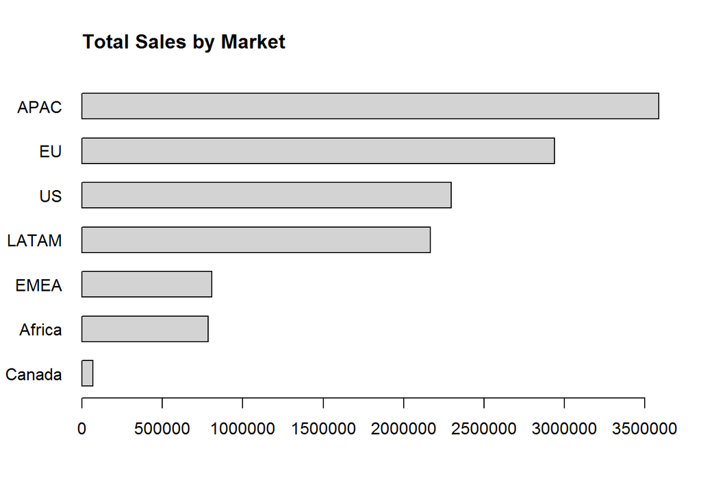

*Does any market appear to be an outlier in total sales?*

**The Canada market has extremely low sales as compared to other markets and can be considered as an outlier.**

*Can you visually indicate this market as a separate color from the others?*

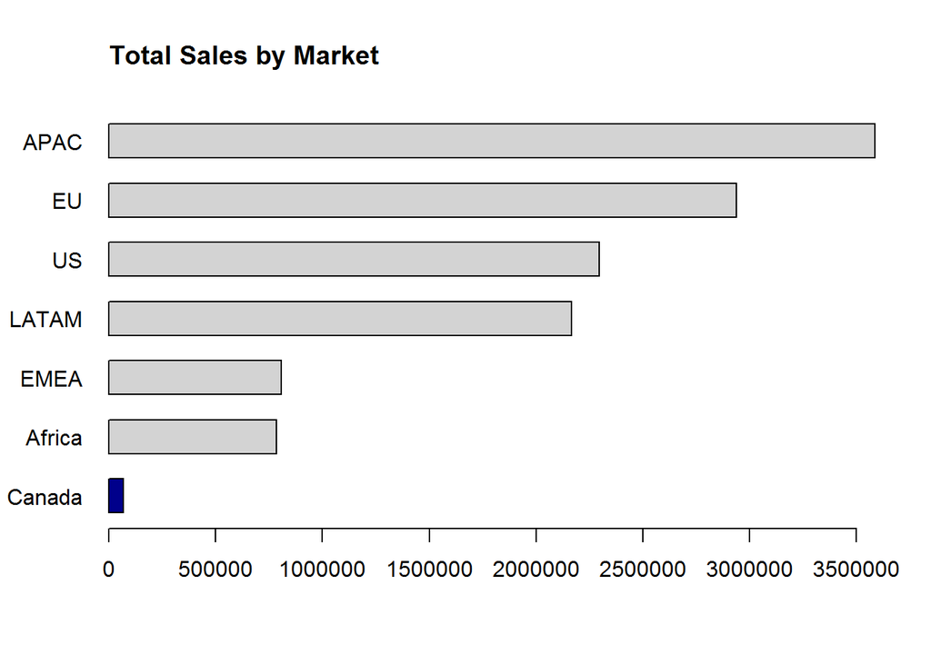

*Step 3 - Create a line chart total sales by year for each market*

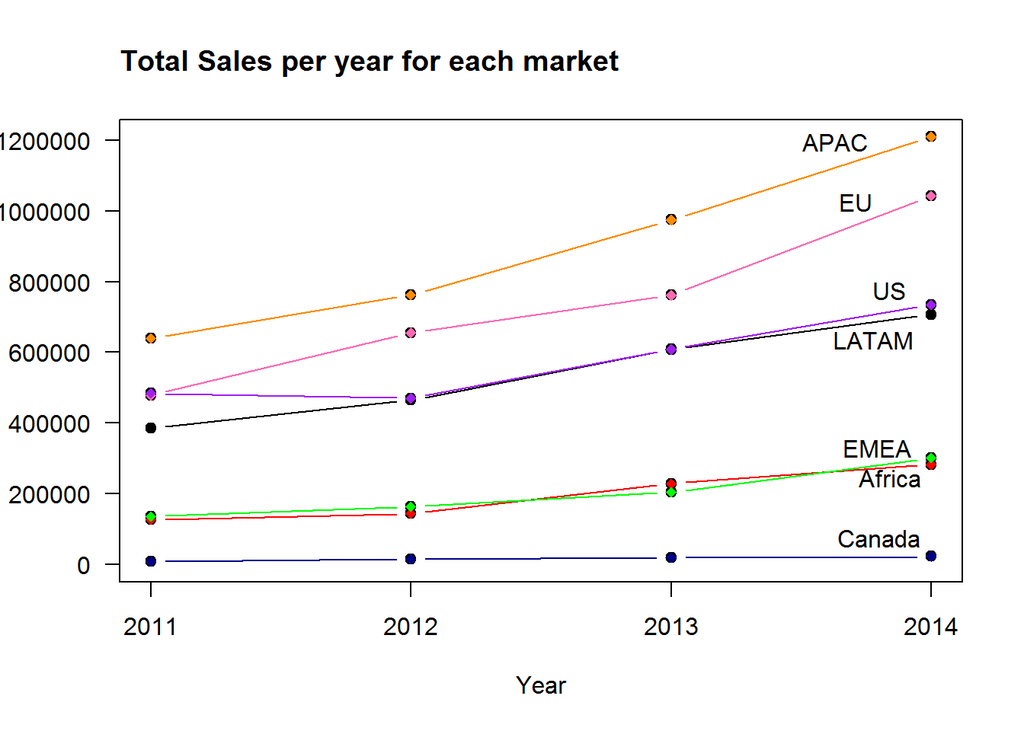

*Does the same market appear to be an outlier in your line graph as well?*

**Yes, the same market appear to be an outlier in the line graph as well.**

*Can you visually indicate this market as a separate color from the other markets in your graph?*

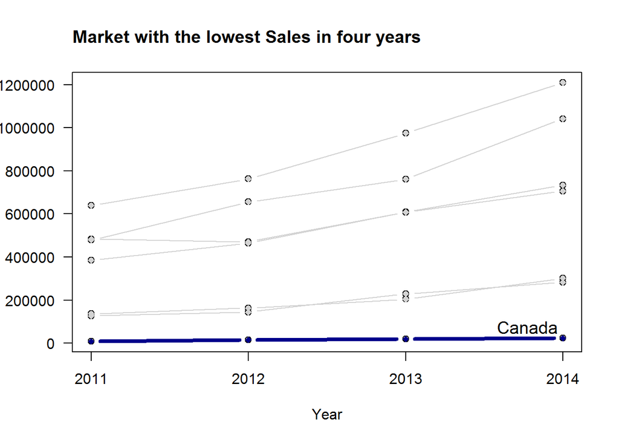

*Step 4 - Create a box plot of total sales by market*

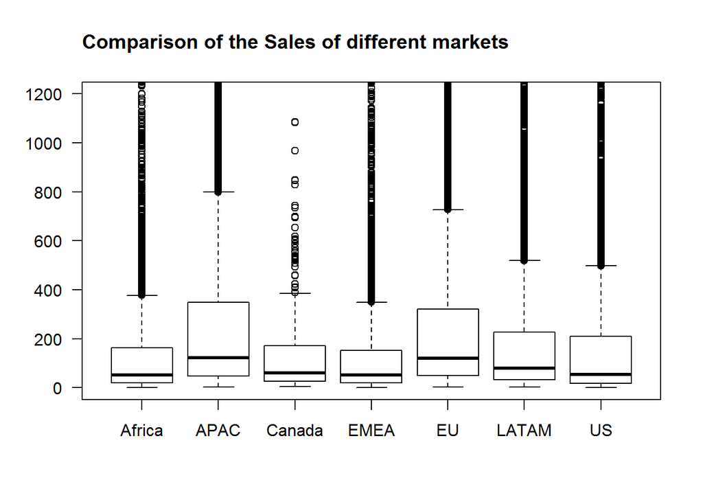

*Does the general pattern you observe match that of the earlier steps 2 and 3?*

**Here, the analysis of the sales have been done on the scale of 0-1200. In this particular scenario the canadian market still has the lowest total sale however, the median sale of Africa, EMEA and US is comparable to that of Canada.**

*What other insights can you draw from your box plot above?*

**For Canadian market, the interquartile range is 145, which means 50% of the sales lie within 25 and 170.**

*Can you visually indicate this market as a separate color from the others in your boxplot graph?*

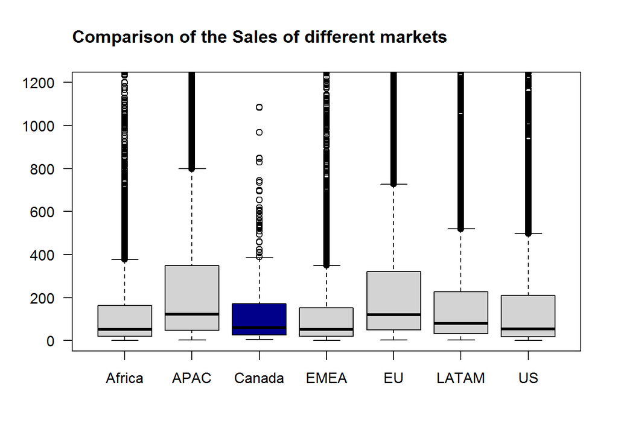

*Step 5 - Determine the relation between the Profit and Sales*

*Not a bar plot, line graph, or box plot*

**The Scatter plot has been used to determine the relation between the Profit and Sales of different products from various Categories. This analysis could be used to further expand the business in Canada which has the lowest Sales.**

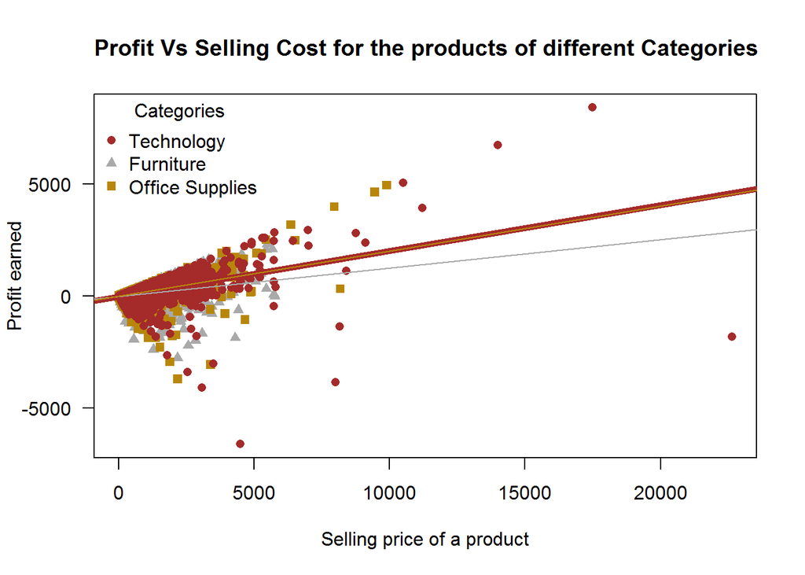